# Assignment 05

Zelin He

2023-02-20

## 1. R Markdown Load and check data

```r
dataset <- read.delim("gapminder.csv", header = TRUE)

cat("There are", nrow(dataset), "rows and", ncol(dataset), "columns.\n")
```

```
## There are 13055 rows and 25 columns.
```

```r
head(dataset)
```

```
##   iso3  name iso2   region                      sub.region intermediate.region
## 1  ABW Aruba   AW Americas Latin America and the Caribbean           Caribbean
## 2  ABW Aruba   AW Americas Latin America and the Caribbean           Caribbean
## 3  ABW Aruba   AW Americas Latin America and the Caribbean           Caribbean
## 4  ABW Aruba   AW Americas Latin America and the Caribbean           Caribbean
## 5  ABW Aruba   AW Americas Latin America and the Caribbean           Caribbean
## 6  ABW Aruba   AW Americas Latin America and the Caribbean           Caribbean
##   time totalPopulation fertilityRate lifeExpectancy childMortality
## 1 1960           54211         4.820         65.662             NA
## 2 1961           55438         4.655         66.074             NA
## 3 1962           56225         4.471         66.444             NA
## 4 1963           56695         4.271         66.787             NA
## 5 1964           57032         4.059         67.113             NA
## 6 1965           57360         3.842         67.435             NA
##   youthFemaleLiteracy youthMaleLiteracy adultLiteracy GDP_PC accessElectricity
```

[output cut: 20 more lines]

Clearly we can see that there are **13055** rows and **25** columns. The sample data looks OK.

## 2. Descriptive statistics

#### 2.1

```r
cat("Country number by iso3:", length(unique(dataset$iso3)))
```

```
## Country number by iso3: 253
```

```r
cat("Country number by iso2:", length(unique(dataset$iso2)))
```

```
## Country number by iso2: 249
```

```r
cat("Country number by name:", length(unique(dataset$name)))
```

```
## Country number by name: 250
```

From iso3, we know there are 253 countries; From iso2, we know there are 249 countries; From name, we know there are 250 countries;

#### 2.2

```r
# This function compares two columns to check how many values in the second column
# corresponds to the first column
compare <- function(col1, col2) {
    result <- data.frame(find = unique(dataset[, col1]),
                         count = integer(length(unique(dataset[, col1]))))
    for (i in 1:nrow(result)) {
        result[i, "count"] =
            length(unique(subset(dataset, dataset[, col1] == result[i, "find"],
                                 select = col2))[, 1])
    }
    print(result)
    result
}

compare1 <- compare("iso2", "name")
```

```
##     find count
## 1     AW     1
## 2     AF     1
## 3     AO     1
## 4     AI     1
## 5     AX     1
## 6     AL     1
## 7     AD     1
## 8     AE     1
## 9     AR     1
## 10    AM     1
## 11    AS     1
## 12    AQ     1
## 13    TF     1
## 14    AG     1
```

[output cut: 235 more lines]

```r
print(unique(dataset[dataset$iso2 == compare1[compare1$count != 1, ]$find, ]$name))
```

```
## [1] ""        "Namibia"
```

From the chart, we can find that iso2 **““** correspond to more than one name, **““** and **“Namibia”**.

##### 2.1.2

```r
compare2 <- compare("name", "iso3")
```

```
##                                                     find count
## 1                                                  Aruba     1
## 2                                            Afghanistan     1
## 3                                                 Angola     1
## 4                                               Anguilla     1
## 5                                          Åland Islands     1
## 6                                                Albania     1
## 7                                                Andorra     1
## 8                                   United Arab Emirates     1
## 9                                              Argentina     1
## 10                                               Armenia     1
## 11                                        American Samoa     1
## 12                                            Antarctica     1
## 13                           French Southern Territories     1
## 14                                   Antigua and Barbuda     1
```

[output cut: 236 more lines]

```r
print(unique(dataset[dataset$name == compare2[compare2$count != 1, ]$find, ]$iso3))
```

```
## [1] "CHANISL"     "GBM"         "KOS"         "NLD_CURACAO"
```

##### 2.1.3

```r
cat("Year max: ", max(dataset$time, na.rm = TRUE))
```

```
## Year max:  2019
```

```r
cat("Year min: ", min(dataset$time, na.rm = TRUE))
```

```
## Year min:  1960
```

From the result we can tell that the minimum year is **1960** and the maximum year is **2019**.

## 3. CO2 emissions

#### 3.1

```r
library(dplyr)
missing_co2 <- dataset %>%
    group_by(time) %>%
    summarise(missing = sum(is.na(co2))) %>%
    arrange(desc(missing))

missing_co2_PC <- dataset %>%
    group_by(time) %>%
    summarise(missing = sum(is.na(co2_PC))) %>%
    arrange(desc(missing))

cat("missing co2 by year:\n")
```

```
## missing co2 by year:
```

```r
print(missing_co2)
```

```
## # A tibble: 61 × 2
##     time missing
##    <int>   <int>
##  1  2017     217
##  2  2018     217
##  3  2019     217
##  4  1960      60
##  5  1961      60
##  6  1962      58
##  7  1963      57
##  8  1964      51
##  9  1965      51
## 10  1966      51
## # … with 51 more rows
```

```r
cat("missing co2 per capita by year:\n")
```

```
## missing co2 per capita by year:
```

```r
print(missing_co2_PC)
```

```
## # A tibble: 61 × 2
##     time missing
##    <int>   <int>
##  1  2017     217
##  2  2018     217
##  3  2019     217
##  4  1960      60
##  5  1961      60
##  6  1962      58
##  7  1963      57
##  8  1964      51
##  9  1965      51
## 10  1966      51
## # … with 51 more rows
```

Missing data sorted by decreasing order is shown above. We can easily found that year **2017, 2018, 2019** have the most missing data.

#### 3.2

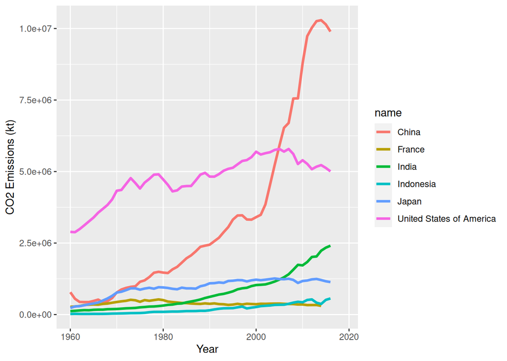

```r
library(ggplot2)

subset_data <- subset(dataset,
                      name %in% c("United States of America", "China", "India",
                                  "France", "Japan", "Indonesia"))

ggplot(subset_data, aes(x = time, y = co2, group = name, color = name)) +
    geom_line(size = 1.2) +
    labs(x = "Year", y = "CO2 Emissions (kt)") +
    scale_x_continuous(limits = c(1960, 2019))
```

#### 3.3

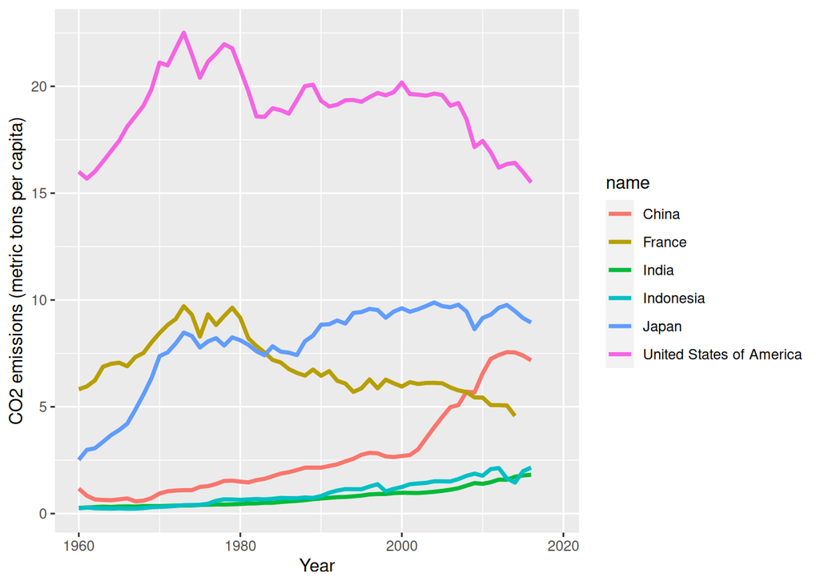

```r
ggplot(subset_data, aes(x = time, y = co2_PC, group = name, color = name)) +
    geom_line(size = 1.2) +
    labs(x = "Year", y = "CO2 emissions (metric tons per capita)") +
    scale_x_continuous(limits = c(1960, 2019))
```

However for *developed countries*, the emission per capita is relatively **constant** even **decreasing**, while in *developing countries* the data is **increasing**; also developed countries have a **higher** emission per capita than developing countries.

#### 3.4

```r
library(tidyr)

avg_co2_pc_by_year_region <- dataset %>%
    group_by(time, region) %>%
    filter(name != "") %>%
    summarize(mean_co2_pc = mean(co2_PC, na.rm = TRUE))
wide_avg_co2_pc_by_year_region <-
    spread(avg_co2_pc_by_year_region, key = region, value = mean_co2_pc) %>%
    select(-V1)
print(wide_avg_co2_pc_by_year_region , n = 100)
```

```
## # A tibble: 61 × 6
## # Groups:   time [61]
##     time  Africa Americas   Asia Europe Oceania
##    <int>   <dbl>    <dbl>  <dbl>  <dbl>   <dbl>
##  1  1960   0.291     7.15   1.74   5.77    2.73
##  2  1961   0.300     7.38   2.06   5.92    2.85
##  3  1962   0.299     7.78   2.36   6.19    2.30
##  4  1963   0.310     7.35   5.00   6.51    2.44
##  5  1964   0.349     7.42   5.18   6.81    3.20
##  6  1965   0.385     7.01   5.39   6.94    3.41
##  7  1966   0.422     6.81   5.02   7.15    3.61
##  8  1967   0.607     8.05   4.68   7.22    3.83
##  9  1968   0.781     7.97   4.57   7.74    4.11
## 10  1969   0.824     9.58   7.17   8.15    4.40
## 11  1970   0.844    10.3    7.82   8.66    4.96
```

[output cut: 50 more lines]

#### 3.5

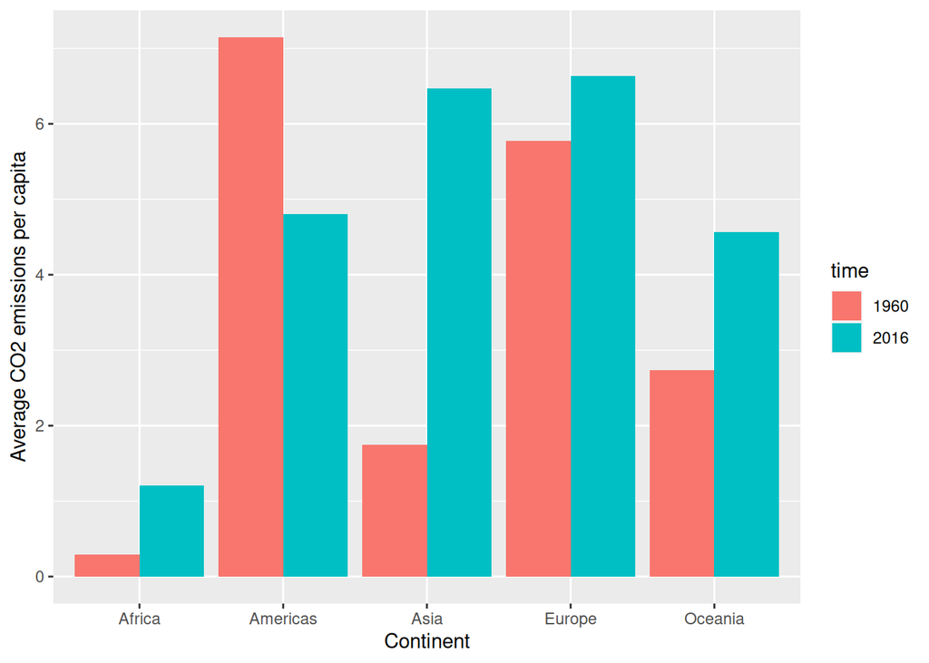

```r
avg_co2_pc_by_year_region <- avg_co2_pc_by_year_region %>%
    filter(time %in% c(1960, 2016)) %>%
    ungroup()
# avg_co2_pc_by_year_region <- melt(avg_co2_pc_by_year_region, id = "time")
avg_co2_pc_by_year_region$time <- as.character(avg_co2_pc_by_year_region$time)

ggplot(avg_co2_pc_by_year_region,
    aes(x = region, y = mean_co2_pc, fill = time)) +
    geom_bar(stat = "identity", position = "dodge") +
    labs(x = "Continent", y = "Average CO2 emissions per capita")
```

The result is same as we discussed in the previous part.

#### 3.6

```r
emitters <- dataset %>%
    group_by(region) %>%
    filter(time == 2016 & region != "") %>%
    filter(!is.na(co2_PC)) %>%
    select("name", "co2_PC")
largest_emitters <- emitters %>% arrange(desc(co2_PC)) %>% slice(1:3)
print("Largest emitters in each continent: ")
```

```
## [1] "Largest emitters in each continent: "
```

```r
print(largest_emitters)
```

```
## # A tibble: 15 × 3
## # Groups:   region [5]
##    region   name                     co2_PC
##    <chr>    <chr>                     <dbl>
##  1 Africa   South Africa               8.48
##  2 Africa   Libya                      7.79
##  3 Africa   Seychelles                 6.39
##  4 Americas Trinidad and Tobago       31.8
##  5 Americas United States of America  15.5
##  6 Americas Canada                    15.1
##  7 Asia     Qatar                     38.9
##  8 Asia     Kuwait                    25.0
##  9 Asia     Bahrain                   22.2
## 10 Europe   Gibraltar                 18.8
## 11 Europe   Luxembourg                15.4
## 12 Europe   Faroe Islands             13.1
## 13 Oceania  New Caledonia             19.3
## 14 Oceania  Australia                 15.5
## 15 Oceania  Palau                     12.6
```

```r
print("Smallest emitters in each continent: ")
```

```
## [1] "Smallest emitters in each continent: "
```

```r
smallest_emitters <- emitters %>% arrange(co2_PC) %>% slice(1:3)
print(smallest_emitters)
```

```
## # A tibble: 15 × 3
## # Groups:   region [5]
##    region   name                              co2_PC
##    <chr>    <chr>                              <dbl>
##  1 Africa   Congo, Democratic Republic of the 0.0256
##  2 Africa   Somalia                           0.0455
##  3 Africa   Burundi                           0.0472
##  4 Americas Haiti                             0.275
##  5 Americas Nicaragua                         0.887
##  6 Americas Honduras                          1.06
##  7 Asia     Afghanistan                       0.245
##  8 Asia     Nepal                             0.334
##  9 Asia     Yemen                             0.390
## 10 Europe   Liechtenstein                     1.36
## 11 Europe   Albania                           1.58
## 12 Europe   Moldova, Republic of              1.83
## 13 Oceania  Solomon Islands                   0.272
## 14 Oceania  Vanuatu                           0.527
## 15 Oceania  Kiribati                          0.587
```

The result is shown above.

## 4. GDP per capita

#### 4.1

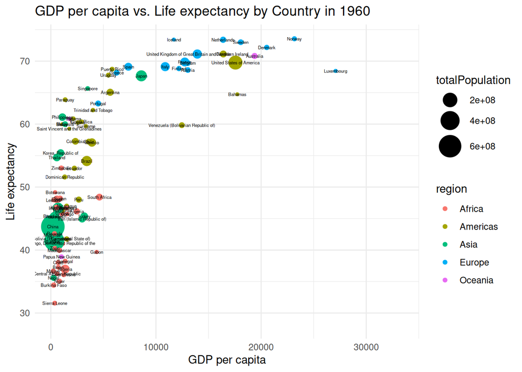

```r
data_1960 <- subset(dataset, time == 1960)
data_1960 <- data_1960[data_1960$region != "", ]

ggplot(data_1960, aes(x = GDP_PC, y = lifeExpectancy)) +
    geom_point(aes(size = totalPopulation, color = region)) +
    scale_size_continuous(range = c(1, 10)) +
    labs(x = "GDP per capita", y = "Life expectancy") +
    theme_minimal() +
    geom_text(aes(label = name), size = 1.5) +
    ggtitle("GDP per capita vs. Life expectancy by Country in 1960")
```

We can find that with greater GDP per capita comes the greater life expectancy; *European* countries have the **highest** GDP per capita and life expectancy, while *Asian* and *African* countries have the **lowest**.

#### 4.2

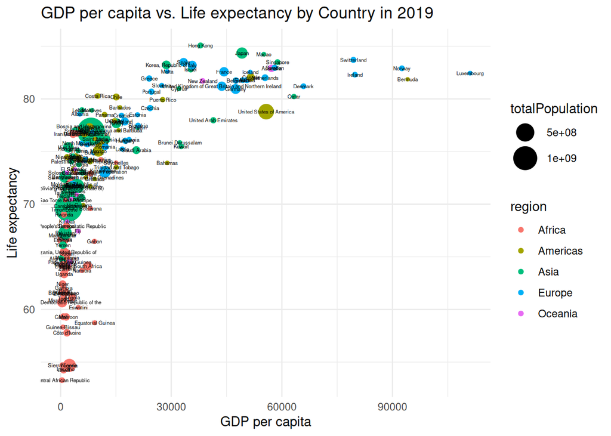

```r
data_2019 <- subset(dataset, time == 2019)
data_2019 <- data_2019[data_2019$region != "", ]

ggplot(data_2019, aes(x = GDP_PC, y = lifeExpectancy)) +
    geom_point(aes(size = totalPopulation, color = region)) +
    scale_size_continuous(range = c(1, 10)) +
    labs(x = "GDP per capita", y = "Life expectancy") +
    theme_minimal() +
    geom_text(aes(label = name), size = 1.5) +
    ggtitle("GDP per capita vs. Life expectancy by Country in 2019")
```

In the 2019 data, the relationship between GDP per capita and life expectancy holds. However, we can observe that *European* countries no longer dominates the high GDP and high LE part; *Asian* countries spreads widely from the highest to mid-low tire, and *African* countries remains the **lowest**.

#### 4.3

We see that *European* countries remains a **high** development level, with *Asian* countries chasing up; *African* countries remains at a **low** level. However, the overall life expectancy and GDP per capita **increases** greatly for every continents and almost every countries.

#### 4.4

```r
my_data <- subset(dataset, select = c("region", "time", "lifeExpectancy"))

avg_life_expectancy <- aggregate(lifeExpectancy ~ region + time,
                                 data = my_data, FUN = mean)

regions <- unique(avg_life_expectancy$region)
avg_life_expectancy <-
    data.frame(region = regions, avg_life_1960 =
        avg_life_expectancy[avg_life_expectancy$time == 1960, ]$lifeExpectancy,
        avg_life_2019 =
        avg_life_expectancy[avg_life_expectancy$time == 2019, ]$lifeExpectancy)

print(avg_life_expectancy)
```

```
##     region avg_life_1960 avg_life_2019
## 1               70.73900      77.79056
## 2   Africa      41.46600      64.11014
## 3 Americas      58.64651      75.83206
## 4     Asia      51.64931      74.61739
## 5   Europe      68.28254      79.35714
## 6  Oceania      56.39613      73.52827
```

The result does **fit** what I see on the figures.

#### 4.5

```r
average_LE_growth_raw <- dataset[dataset$region != "", ] %>%
    group_by(region, time) %>%
    summarize(avg_life_expectancy = mean(lifeExpectancy, na.rm = TRUE)) %>%
    ungroup()
average_LE_growth_raw <- average_LE_growth_raw[complete.cases(average_LE_growth_raw),]

average_LE_growth <- data.frame(time = unique(average_LE_growth_raw$time))

for (i in unique(average_LE_growth_raw$region)) {
    tmp <- average_LE_growth_raw %>%
        filter(region == i) %>%
        mutate(prev = lag(avg_life_expectancy), growth = avg_life_expectancy - prev) %>%
        select(time, growth) %>%
        rename(!!paste("growth", i) := growth)
    average_LE_growth <- merge(average_LE_growth, tmp, by = "time")
}

print(average_LE_growth)
```

```
##    time growth Africa growth Americas growth Asia growth Europe growth Oceania
## 1  1960            NA              NA          NA            NA             NA
## 2  1961   0.454719811      0.46854500   0.9654719   0.404879737     0.39752923
## 3  1962   0.451028868      0.42744833   0.5497061   0.026223947     0.41735462
## 4  1963   0.446655849      0.40983056   0.1879937   0.288938684     0.40544846
## 5  1964   0.443080943      0.41888417   0.5769823   0.435213947     0.40706462
## 6  1965   0.440459245      0.61391438   0.5709571   0.124273421     0.39704615
## 7  1966   0.440158868      0.16557368   0.9325241   0.222472368     0.39673923
## 8  1967   0.442124717      0.39116861   0.5300773   0.139385000     0.43325538
## 9  1968   0.447120000      0.35944500   0.5161100   0.084329211     0.37236538
## 10 1969   0.453500377      0.39022500   0.4956992  -0.002333684     0.41817846
## 11 1970   0.462091509      0.59014582   0.4826651   0.257063421     0.36819538
## 12 1971   0.472835660      0.18241613   0.4402896   0.130770526     0.41496385
## 13 1972   0.482558679      0.36825639   0.3747812   0.268090263     0.40131923
## 14 1973   0.490199811      0.37900083   0.3812135   0.246453887     0.38054385
```

[output cut: 46 more lines]

The growth of life expectancy **decelerates** as it gets higher. It might be cause there is a certain limit for human life, and it would get harder to harder to approach the limit.

#### 4.6

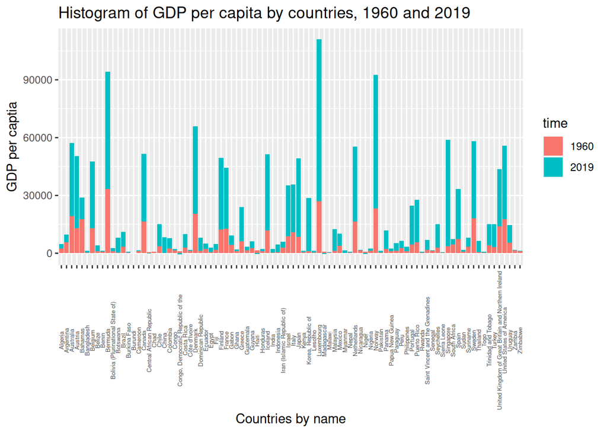

```r
gdp_pc_data <- dataset %>%
    select(name, GDP_PC, time) %>%
    filter(time %in% c(1960, 2019), name != "") %>%
    group_by(name) %>%
    filter(!any(is.na(`GDP_PC`)), 1960 %in% time & 2019 %in% time) %>%
    ungroup()

gdp_pc_data$time = as.character(gdp_pc_data$time)
gdp_pc_data[gdp_pc_data$time == 2019, ]$GDP_PC = gdp_pc_data[gdp_pc_data$time == 2019, ]$GDP_PC -
    gdp_pc_data[gdp_pc_data$time == 1960, ]$GDP_PC

ggplot(data = gdp_pc_data, aes(x = `name`, y = `GDP_PC`, fill = `time`)) +
    geom_bar(stat="identity") +
    geom_col(position = position_stack(reverse = TRUE)) +
    xlab("Countries by name") +
    ylab("GDP per captia") +
    ggtitle("Histogram of GDP per capita by countries, 1960 and 2019") +
    theme(axis.text.x = element_text(angle = 90, vjust = 0.5, size = 5))
```

#### 4.7

```r
rank_1960 <- dataset %>%
    filter(time == 1960, name != "", lifeExpectancy != "") %>%
    mutate(rank = rank(-lifeExpectancy)) %>%
    select("iso2", rank)

cat("The rank of LE of USA in the world in 1960 is",
    rank_1960[rank_1960$iso2 == "US", ]$rank, "\n")
```

```
## The rank of LE of USA in the world in 1960 is 17
```

```r
rank_2019 <- dataset %>%
    filter(time == 2019, iso3 != "", lifeExpectancy != "") %>%
    mutate(rank = rank(-lifeExpectancy)) %>%
    select("iso2", rank)

cat("The rank of LE of USA in the world in 2019 is",
    rank_2019[rank_2019$iso2 == "US", ]$rank, "\n")
```

```
## The rank of LE of USA in the world in 2019 is 47
```

The ranking of US in 1960 is **17** and the ranking of US in 2019 is **47**.

#### 4.8

```r
cat("The relative rank of LE of USA in the world in 1960 is",
    rank_1960[rank_1960$iso2 == "US", ]$rank / nrow(rank_1960), "\n")
```

```
## The relative rank of LE of USA in the world in 1960 is 0.09042553
```

```r
cat("The relative rank of LE of USA in the world in 2019 is",
    rank_2019[rank_2019$iso2 == "US", ]$rank / nrow(rank_2019), "\n")
```

```
## The relative rank of LE of USA in the world in 2019 is 0.2373737
```

The relative ranking of US dropped from **0.09042553** in 1960 to **0.2373737** in 2019, which means even after considered many new countries appears, the ranking of US the life expectancy in the world still **dropped** quite a bit.